# Problem Set 3

Elaine Li and Saurabh Kalra

October 21, 2018

**Front matter**

This submission is my work alone and complies with the 30531 integrity policy.

Add your initials to indicate your agreement: **EL & SK**

```r
# LOAD LIBRARIES HERE
library(tidyverse)
library(ggplot2)
library(nycflights13)
library(dplyr)
library(tidyr)
library(Hmisc)
library(haven)
```

# 1 R4DS Exercises

## 1.1 Transformations: Summarizing Grouped Data

Ans 1.1.1.a.

327,346 flights were not cancelled.

```r
not_cancelled <- filter(flights, !is.na(dep_delay), !is.na(arr_delay))

not_cancelled %>%
  group_by(carrier) %>%
  summarise(
    n(),
    min(distance),
    max(distance)
  ) %>%
  arrange(desc(carrier))
```

```
## # A tibble: 16 x 4
##    carrier `n()` `min(distance)` `max(distance)`
##    <chr>   <int>           <dbl>           <dbl>
##  1 YV        544              96             544
##  2 WN      12044             169            2133
##  3 VX       5116            2248            2586
##  4 US      19831              94            2153
##  5 UA      57782             116            4963
##  6 OO         29             229            1008
##  7 MQ      25037             184            1147
##  8 HA        342            4983            4983
##  9 FL       3175             397             762
## 10 F9        681            1620            1620
## 11 EV      51108              80            1389
## 12 DL      47658              94            2586
## 13 B6      54049             173            2586
## 14 AS        709            2402            2402
## 15 AA      31947             187            2586
## 16 9E      17294              94            1587
```

Ans 1.1.1.b

The following airlines only offer flights from New York City airports to one other airport:

- AS - Alaka Airlines
- F9 - Frontier Airlines
- HA - Hawaiian Airlines

```r
not_cancelled %>%
  group_by(carrier, dest) %>%
  summarise(n()) %>%
  summarise(n_destinations = n_distinct(dest)) %>%
  arrange(n_destinations)
```

```
## # A tibble: 16 x 2
##    carrier n_destinations
##    <chr>            <int>
##  1 AS                   1
##  2 F9                   1
##  3 HA                   1
##  4 FL                   3
##  5 YV                   3
##  6 OO                   5
##  7 US                   5
##  8 VX                   5
##  9 WN                  11
## 10 AA                  19
## 11 MQ                  20
## 12 DL                  40
## 13 B6                  42
## 14 UA                  47
## 15 9E                  48
## 16 EV                  61
```

Ans 1.1.2

- From a passengers’ perspective, arrival delay is more important because departure delay only accounts for the delay while at the origin city whereas arrival delay accounts for the delay leaving from origin city, delay while in air, time spent rerouting, and/or time made up while in air.

Ans 1.1.3.a

```r
median_arr_delay <-
  flights %>%
  group_by(carrier) %>%
  na.omit(flights) %>%
  summarise(pct_50 = quantile(arr_delay, 0.5))

print(median_arr_delay)
```

```
## # A tibble: 16 x 2
##    carrier pct_50
##    <chr>    <dbl>
##  1 9E          -7
##  2 AA          -9
##  3 AS         -17
##  4 B6          -3
##  5 DL          -8
##  6 EV          -1
##  7 F9           6
##  8 FL           5
##  9 HA         -13
## 10 MQ          -1
## 11 OO          -7
## 12 UA          -6
## 13 US          -6
## 14 VX          -9
## 15 WN          -3
## 16 YV          -2
```

Ans 1.1.3.b

Ans 1.1.3.c

- average arrival delay of flights
- the interquartile range (IQR) of arrival delays
- mean absolute deviation of arrival delays
- standard deviation of arrival delay time

Ans 1.1.3.d

Across the four metrics, these airlines have consistently ranked amongst the most delayed:

- Frontier Airlines (F9)
- Mesa Airlines (YV)
- AirTran Airways (FL)
- ExpressJet Airways (EV)
- Endeavor Air (9E)

```r
assess_arr_delay <-
  flights %>%
  group_by(carrier) %>%
  na.omit() %>%
  summarise(
    avg_delay = mean(arr_delay),
    iqr_delay = IQR(arr_delay),
    sd_delay = sd(arr_delay),
    mad_delay = mad(arr_delay)
  ) %>%
  arrange(desc(avg_delay))

print(assess_arr_delay)
```

```
## # A tibble: 16 x 5
##    carrier avg_delay iqr_delay sd_delay mad_delay
##    <chr>       <dbl>     <dbl>    <dbl>     <dbl>
##  1 F9         21.9        40       61.6      26.7
##  2 FL         20.1        31       54.1      20.8
##  3 EV         15.8        40       49.9      23.7
##  4 YV         15.6        40.2     52.9      25.2
##  5 OO         11.9        22       48.6      14.8
##  6 MQ         10.8        31       43.2      20.8
##  7 WN          9.65       30       46.9      20.8
##  8 B6          9.46       31       42.8      20.8
##  9 9E          7.38       36       50.1      23.7
## 10 UA          3.56       30       41.0      20.8
## 11 US          2.13       23       33.1      16.3
## 12 VX          1.76       31       50.0      22.2
## 13 DL          1.64       28       44.4      19.3
## 14 AA          0.364      29       42.5      20.8
## 15 HA         -6.92       30.5     75.1      22.2
## 16 AS         -9.93       34       36.5      25.2
```

Ans 1.1.4

```r
# Given Method
not_cancelled %>% count(dest)
```

```
## # A tibble: 104 x 2
##    dest      n
##    <chr> <int>
##  1 ABQ     254
##  2 ACK     264
##  3 ALB     418
##  4 ANC       8
##  5 ATL   16837
##  6 AUS    2411
##  7 AVL     261
##  8 BDL     412
##  9 BGR     358
## 10 BHM     269
## # ... with 94 more rows
```

```r
# Alternative Method
not_cancelled %>%
  group_by(dest) %>%
  summarise(n())
```

```
## # A tibble: 104 x 2
##    dest  `n()`
##    <chr> <int>
##  1 ABQ     254
##  2 ACK     264
##  3 ALB     418
##  4 ANC       8
##  5 ATL   16837
##  6 AUS    2411
##  7 AVL     261
##  8 BDL     412
##  9 BGR     358
## 10 BHM     269
## # ... with 94 more rows
```

```r
# Given Method
not_cancelled %>% count(tailnum, wt = distance)
```

```
## # A tibble: 4,037 x 2
##    tailnum      n
##    <chr>    <dbl>
##  1 D942DN    3418
##  2 N0EGMQ  239143
##  3 N10156  109664
##  4 N102UW   25722
##  5 N103US   24619
##  6 N104UW   24616
##  7 N10575  139903
##  8 N105UW   23618
##  9 N107US   21677
## 10 N108UW   32070
## # ... with 4,027 more rows
```

```r
# Alternative Method
not_cancelled %>%
  group_by(tailnum) %>%
  tally(wt = distance)
```

```
## # A tibble: 4,037 x 2
##    tailnum      n
##    <chr>    <dbl>
##  1 D942DN    3418
##  2 N0EGMQ  239143
##  3 N10156  109664
##  4 N102UW   25722
##  5 N103US   24619
##  6 N104UW   24616
##  7 N10575  139903
##  8 N105UW   23618
##  9 N107US   21677
## 10 N108UW   32070
## # ... with 4,027 more rows
```

Ans 1.1.5.

- The two days that are extreme outliers are:
  - February 8, 2013
  - February 9, 2013
- It is possible that these two days were blizzard days that made it difficult for flights to take off or land in the New York area. The backlog of flights from the first day probably then rolled over to the second day as carriers tried to reschedule or reroute passengers.

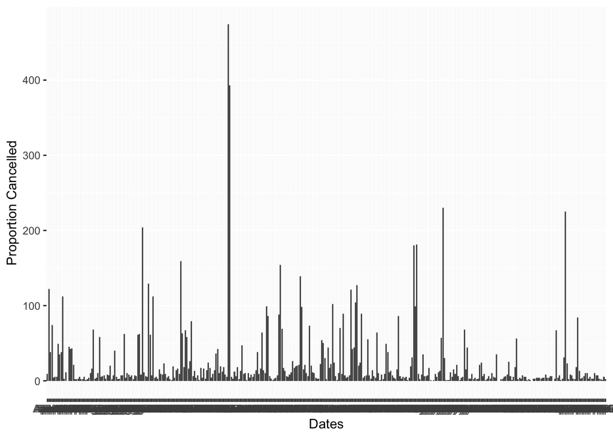

```r
flights <-
  flights %>%
  group_by(month, day) %>%
  mutate(
    num_flights = n(),
    cancelled = ifelse(is.na(arr_time), 1, 0),
    num_cancelled = sum(cancelled == 1),
    prop_cancelled = (num_cancelled / num_flights),
    dates = paste(month.abb[month], day, sep = "-")
  )

ggplot(flights) +
  geom_bar(aes(
    x = dates,
    y = (num_cancelled / num_flights)
  ),
  stat = "identity"
  ) +
  labs(
    x = "Dates",
    y = "Proportion Cancelled"
  )
```

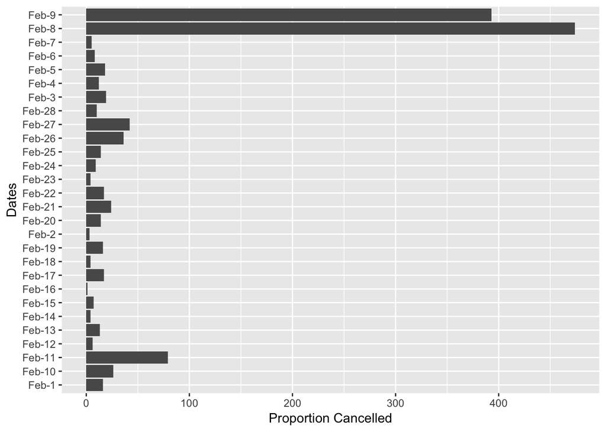

```r
# Recognizing that the outliers fall in February, we filter to zoom in to Feb.
ggplot(flights %>% filter(month == 2)) +
  geom_bar(aes(
    x = dates,
    y = (num_cancelled / num_flights)
  ),
  stat = "identity"
  ) +
  labs(
    x = "Dates",
    y = "Proportion Cancelled"
  ) +
  coord_flip()
```

Ans 1.1.6

- Flights to Columbia, SC experience the worse delay times while flights to Lexington, Kentucky experience the least amount of delay time.

```r
avg_delays_by_dest <-
  flights %>%
  group_by(dest) %>%
  na.omit() %>%
  summarise(average_delay_mins = mean(arr_delay)) %>%
  mutate(rank_dest = rank(-average_delay_mins)) %>%
  arrange(rank_dest)

print(avg_delays_by_dest)
```

```
## # A tibble: 104 x 3
##    dest  average_delay_mins rank_dest
##    <chr>              <dbl>     <dbl>
##  1 CAE                 41.8         1
##  2 TUL                 33.7         2
##  3 OKC                 30.6         3
##  4 JAC                 28.1         4
##  5 TYS                 24.1         5
##  6 MSN                 20.2         6
##  7 RIC                 20.1         7
##  8 CAK                 19.7         8
##  9 DSM                 19.0         9
## 10 GRR                 18.2        10
## # ... with 94 more rows
```

## 1.2 Transformations:Grouped operations with mutate() and (filter())

Ans1.2.1.

*N15910 has most minutes of delay. It was found out by summing minutes of all arrival delays of a particular tailnum and then arranging in descending order.

```r
not_cancelled <-
  flights %>%
  filter(!is.na(dep_delay), !is.na(arr_delay))

not_cancelled %>%
  group_by(tailnum) %>%
  summarise(sumdelay = sum(arr_delay)) %>%
  arrange(desc(sumdelay))
```

```
## # A tibble: 4,037 x 2
##    tailnum sumdelay
##    <chr>      <dbl>
##  1 N15910      7317
##  2 N15980      7134
##  3 N16919      6904
##  4 N228JB      6778
##  5 N14998      6087
##  6 N192JB      5810
##  7 N292JB      5804
##  8 N12921      5788
##  9 N13958      5620
## 10 N10575      5566
## # ... with 4,027 more rows
```

Ans1.2.2. If you want to avoid delays as much as possible, you should fly in the early mornings at 05 hour flights as we can see from the plot.

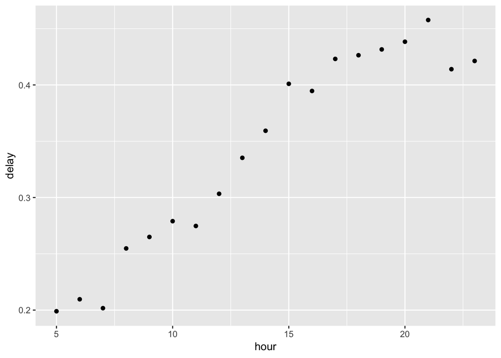

```r
not_cancelled %>%
  group_by(hour) %>%
  summarise(delay = sum(arr_delay > 5) / n()) %>%
  ggplot(aes(x = hour, y = delay)) +
  geom_point()
```

Ans1.2.3. All the destinations that are flown by at least two carriers.

```r
flights %>%
  group_by(dest) %>%
  summarise(flownby = n_distinct(carrier)) %>%
  filter(flownby >= 2)
```

```
## # A tibble: 76 x 2
##    dest  flownby
##    <chr>   <int>
##  1 ATL         7
##  2 AUS         6
##  3 AVL         2
##  4 BDL         2
##  5 BGR         2
##  6 BNA         5
##  7 BOS         7
##  8 BQN         2
##  9 BTV         3
## 10 BUF         4
## # ... with 66 more rows
```

Ans 1.2.4a Used lag(), arrange and group_by function to arrange data.

Ans1.2.4b Plotted the previous flight delay with departure delay. Points were clutterred - used jitter and alpha for better visualization.

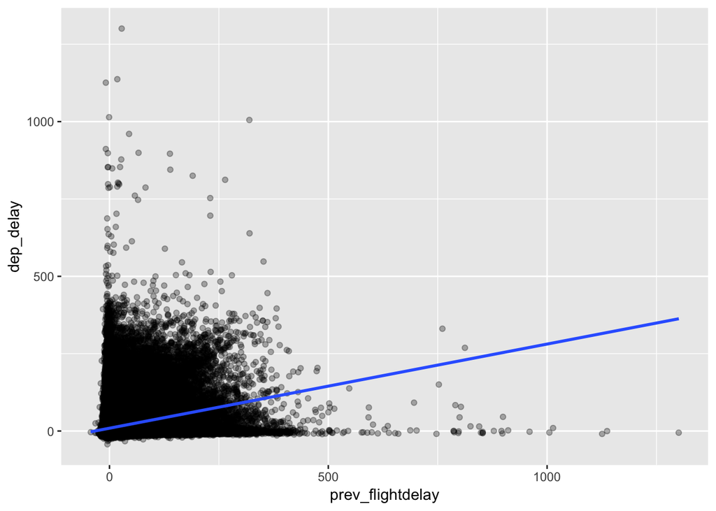

```r
not_cancelled %>%
  group_by(origin) %>%
  arrange(year, month, day, hour, minute) %>%
  filter(!is.na(dep_delay)) %>%
  mutate(prev_flightdelay = lag(dep_delay)) %>%

  ggplot(aes(x = prev_flightdelay, y = dep_delay)) +
  geom_point(alpha = 0.3, position = position_jitter()) +
  geom_smooth(method = "lm")
```

Ans1.2.5a. Computed below airtime and medianairtime table. Most delayed flights that was delayed are arranged.

```r
not_cancelled %>%
  group_by(dest) %>%
  mutate(medianairtime = median(air_time), diff = air_time - medianairtime) %>%
  select(year, month, day, dest, air_time, medianairtime, diff, hour) %>%
  arrange(desc(diff))
```

```
## # A tibble: 327,346 x 8
## # Groups:   dest [104]
##     year month   day dest  air_time medianairtime  diff  hour
##    <int> <int> <int> <chr>    <dbl>         <dbl> <dbl> <dbl>
##  1  2013     7    28 SFO        490           345   145    17
##  2  2013     1    28 EGE        382           253   129    17
##  3  2013    11    22 LAX        440           328   112    18
##  4  2013     9    10 DEN        331           225   106    15
##  5  2013     6    29 ACK        141            41   100     8
##  6  2013    11    22 LAS        399           301    98    17
##  7  2013     1     2 OKC        286           190    96    19
##  8  2013     1    15 OKC        284           190    94    19
##  9  2013     7    10 LAX        422           328    94    18
## 10  2013    12     6 SFO        438           345    93    17
## # ... with 327,336 more rows
```

Ans1.2.5b. Flights are arranged according to speed in air.

```r
not_cancelled %>%
  group_by(dest) %>%
  mutate(speed = distance / air_time) %>%
  select(
    year, month, day, dest, air_time, speed, hour, minute, dep_delay,
    flight, carrier
  ) %>%
  arrange(desc(speed))
```

```
## # A tibble: 327,346 x 11
## # Groups:   dest [104]
##     year month   day dest  air_time speed  hour minute dep_delay flight
##    <int> <int> <int> <chr>    <dbl> <dbl> <dbl>  <dbl>     <dbl>  <int>
##  1  2013     5    25 ATL         65 11.7     17      0         9   1499
##  2  2013     7     2 MSP         93 10.8     15     13        45   4667
##  3  2013     5    13 GSP         55 10.8     20     25        15   4292
##  4  2013     3    23 BNA         70 10.7     19     10         4   3805
##  5  2013     1    12 PBI        105  9.86    16      0        -1   1902
##  6  2013    11    17 SJU        170  9.4      6     55        -5    315
##  7  2013     2    21 SJU        172  9.29    23     58        -3    707
##  8  2013    11    17 STT        175  9.27     8      0        -1    936
##  9  2013    11    16 SJU        173  9.24    19     25        38    347
## 10  2013    11    16 SJU        173  9.24    23     59       -10   1503
## # ... with 327,336 more rows, and 1 more variable: carrier <chr>
```

Ans1.2.6 Counted number of flights before the first delay of greater than 1 hour.

```r
not_cancelled %>%
  arrange(tailnum, time_hour) %>%
  group_by(tailnum) %>%
  mutate(delay_more_than1hr = dep_delay > 60) %>%
  mutate(Before_firstdelay = cumsum(delay_more_than1hr)) %>%
  filter(Before_firstdelay < 1) %>%
  count() %>%
  arrange(-n)
```

```
## # A tibble: 3,804 x 2
## # Groups:   tailnum [3,804]
##    tailnum     n
##    <chr>   <int>
##  1 N954UW    206
##  2 N952UW    162
##  3 N957UW    141
##  4 N5FAAA    117
##  5 N516JB    100
##  6 N38727     99
##  7 N3742C     98
##  8 N5EWAA     97
##  9 N705TW     97
## 10 N765US     97
## # ... with 3,794 more rows
```

## 1.3 Exploratory Data Analysis

### 1.3.1 EDA: Exploring variation

Ans1.3.1.1a Overall pattern suggests, there are less diamonds that are expensive, more quantity of diamonds are available that are cheaper. Histogram of diamonds$price is skewed to right / positive. yes it fits the expectation as more buyers will be for low cost diamonds than expensive ones. Another explanation is that expensive diamonds must be rare so less quantity available.

```r
print(summary(diamonds$price))
```

```
##    Min. 1st Qu.  Median    Mean 3rd Qu.    Max.
##     326     950    2401    3933    5324   18823
```

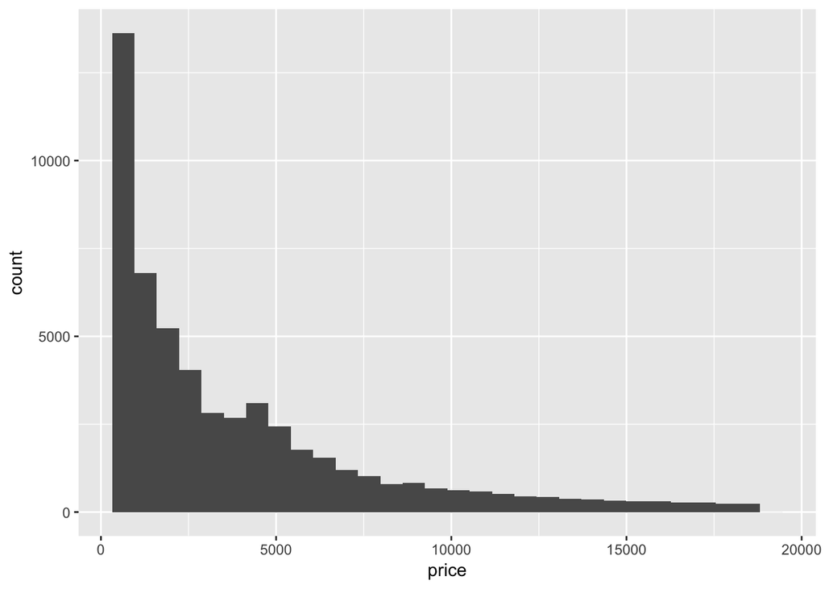

```r
ggplot(data = diamonds, aes(price)) +
  geom_histogram()
```

Ans1.3.1.1.b. Yes, there is a surprising thing in the diamonds data. Diamonds are less availablecompared to other values for price around $1400. We see a white gap when bins were increased or binwidth was reduced.

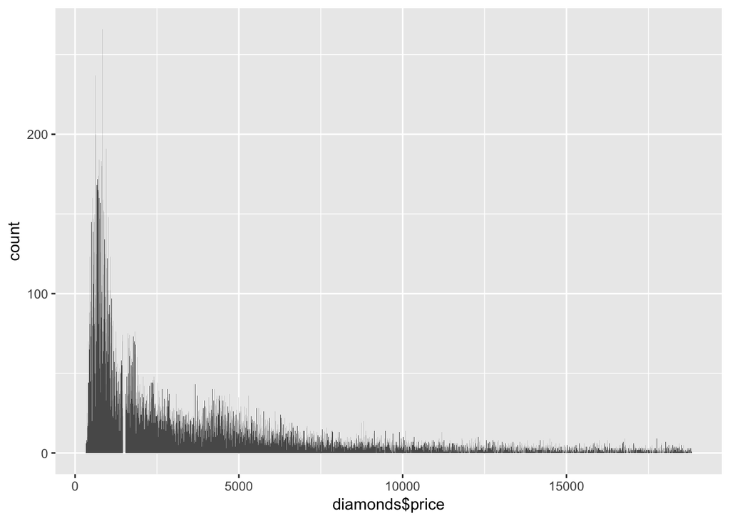

```r
ggplot(data = diamonds, aes(diamonds$price)) +
  geom_histogram(bins = 5000)
```

Ans1.3.1.2a. Data is skewed to right. Yes, it fits our expectations that less diamonds are available for (carats > 2). So the count for higher prices was lower.  
Also as they are less in market or availability they are expensive.

```r
print(summary(diamonds$carat))
```

```
##    Min. 1st Qu.  Median    Mean 3rd Qu.    Max.
##  0.2000  0.4000  0.7000  0.7979  1.0400  5.0100
```

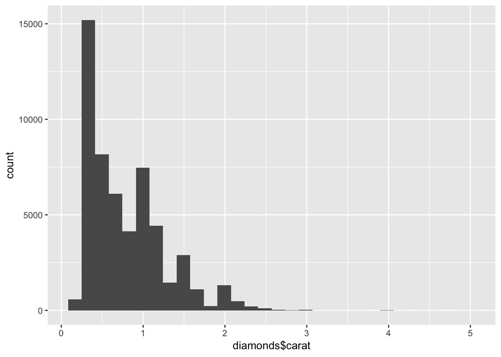

```r
ggplot(data = diamonds, aes(diamonds$carat)) +
  geom_histogram()
```

Ans1.3.1.2b. There are 23 diamonds that are .99 carats and 1558 diamonds that are 1 carat. This may be because it is easier to sell something that is a round number like 1 (as opposed to .99) because more is better for the consumer. In the consumer’s mind, moving from a <1 carat to a 1 carat diamond is like moving into another level.

```r
diamonds %>%
  filter(carat == 1 | carat == .99) %>%
  group_by(carat) %>%
  summarise(n())
```

```
## # A tibble: 2 x 2
##   carat `n()`
##   <dbl> <int>
## 1  0.99    23
## 2  1     1558
```

Ans1.3.1.3 Using coord_cartesian() and its xlim/ylim arguments changes x and y axis limits by zooming into the plot and does not change the underlying data. If we were to just use xlim and ylim, if observations are not in this range, they will be dropped.

Binwidth is how wide the bins are. If we leave binwidth on default, it attempts to calculate bin width by taking the range of the values in our variable and divide it by the default bins = 30. Setting binwidth overrides bins. It is best for the researcher to set binwidth that will allow for best viewing.

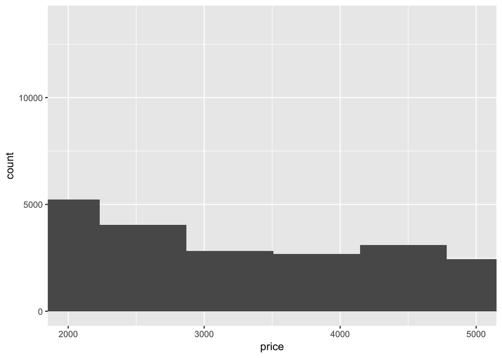

```r
ggplot(data = diamonds, aes(price)) +
  geom_histogram() +
  coord_cartesian(xlim = c(2000, 5000))
```

```
## Warning: Removed 38917 rows containing non-finite values (stat_bin).
```

```
## Warning: Removed 2 rows containing missing values (geom_bar).
```

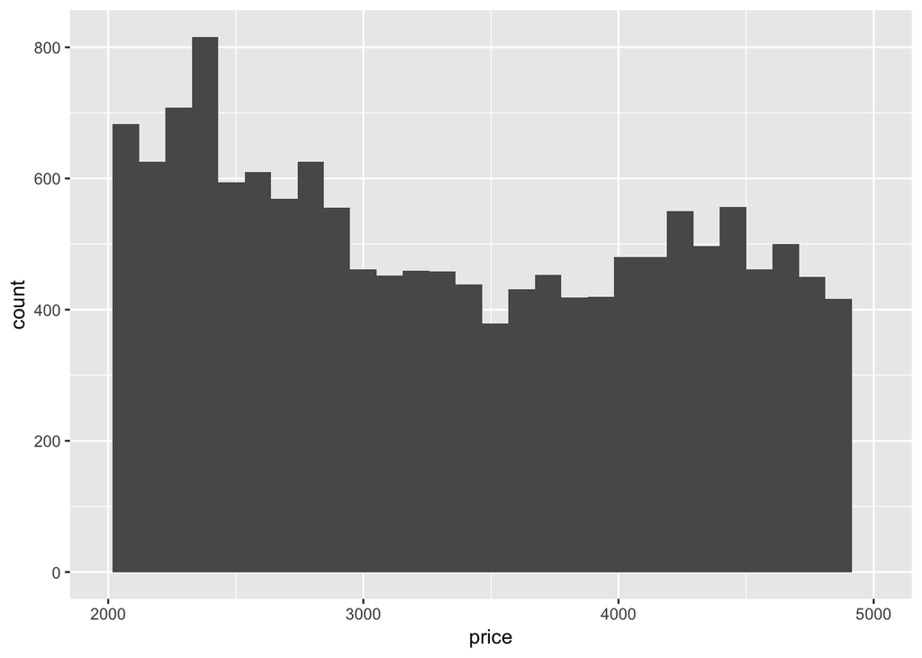

```r
ggplot(data = diamonds, aes(price)) +
  geom_histogram() +
  xlim(2000, 5000)
```

### 1.3.2 1.3.2 EDA: Navigating NAs

Ans1.3.2.1 Missing values are omitted when constructing a histogram, which is created to represent continuous variables. By default, missing values (NAs) are removed with a warning. If we include na.rm=TRUE, missing values are silently removed. Bar charts are created for categorical values and recognizes strings such as “NA”. Thus, all the NAs are “counted” and considered its own category.

Ans1.3.2.2 In mean() and sum(), na.rm=TRUE strips missing values before starting to calculate the mean and the sum.

# 2 Public Sector Application:When should they Mayor’s tourism office host their convention?

## 2.1 Download BTS data

```r
knitr::opts_knit$set(root.dir = "/Users/apple/Desktop/skills1")
library(data.table)
file_names <- dir("/Users/apple/Desktop/skills1") # where you have your files


library(readr)
library(dplyr)
chi.flights <- lapply(file_names, read_csv) %>% bind_rows()
```

## 2.2 Choose a month

Ans 2.1.1 Average arrival delays into either Chicago ORD or MDW are the lowest during the first quarter (especially at the end of January and parts of February), in early Spring (end of March/early April), around Thanksgiving week and in the early summer (May). Days in which at least 80% of flights are on time typically fall in the winter (Jan/Feb), early Spring (end of March/early April), early summer (May), and around end of November.

```r
chi.flights.delay <-
  chi.flights %>%
  filter(DEST == "ORD" | DEST == "MDW") %>%
  group_by(FL_DATE) %>%
  summarise(AVG_DELAY_BY_DAY = mean(ARR_DELAY, na.rm = TRUE),
            TOTAL_FL_BY_DAY = n(),
            AVG_DAY_OF_WEEK = mean(DAY_OF_WEEK, na.rm = TRUE)) %>%
  arrange(AVG_DELAY_BY_DAY
  )

ONTIME_FL_BY_DAY <- chi.flights %>%
  filter(DEST == "ORD" | DEST == "MDW") %>%
  group_by(FL_DATE) %>%
  mutate(ON_TIME = ifelse(ARR_DELAY <= 0, 1, 0)) %>%
  filter(ON_TIME == 1) %>%
  summarise(ON_TIME = n()
  )

chi.flights.delay$ON_TIME <- ONTIME_FL_BY_DAY$ON_TIME

chi.flights.delay <-
  chi.flights.delay %>%
  mutate(PROP_ON_TIME = ON_TIME / TOTAL_FL_BY_DAY,
         PROP_ON_TIME_80 = PROP_ON_TIME >= .8)

print(chi.flights.delay)
```

```
## # A tibble: 366 x 7
##    FL_DATE    AVG_DELAY_BY_DAY TOTAL_FL_BY_DAY AVG_DAY_OF_WEEK ON_TIME
##    <date>                <dbl>           <int>           <dbl>   <int>
##  1 2016-01-30            -15.7             641               6     509
##  2 2016-02-20            -14.8             679               6     644
##  3 2016-11-24            -14.5             514               4     516
##  4 2016-02-01            -14.5             862               1     484
##  5 2016-02-07            -13.4             686               7     618
##  6 2016-05-29            -12.9             755               7     687
##  7 2016-02-27            -12.7             680               6     655
##  8 2016-02-06            -11.6             638               6     578
##  9 2016-09-04            -11.6             737               7     373
## 10 2016-09-03            -11.4             674               6     459
## # ... with 356 more rows, and 2 more variables: PROP_ON_TIME <dbl>,
## #   PROP_ON_TIME_80 <lgl>
```

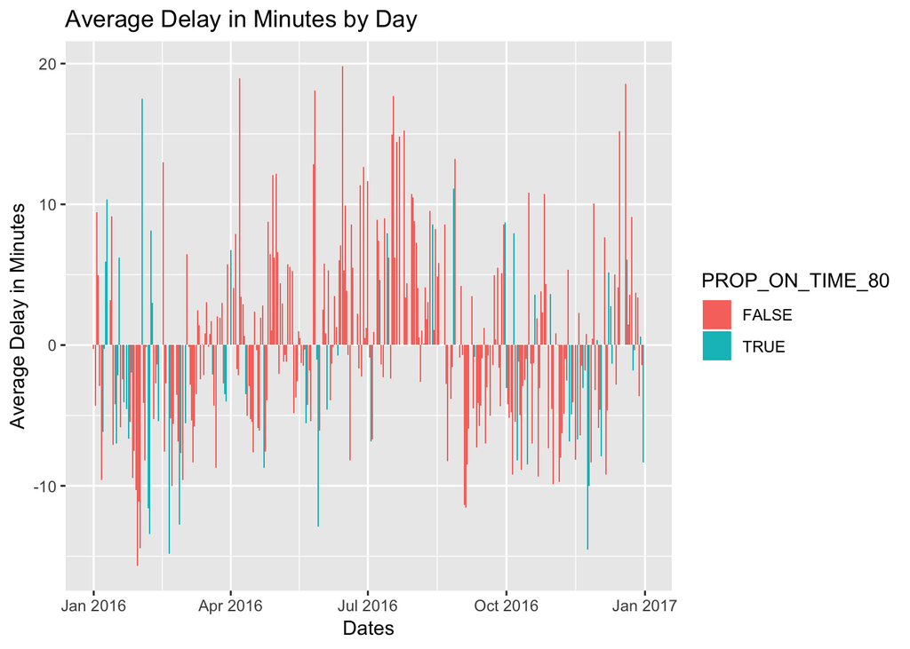

```r
ggplot(chi.flights.delay %>% filter(AVG_DELAY_BY_DAY <= 20)) +
  geom_bar(aes(x = FL_DATE,
               y = AVG_DELAY_BY_DAY,
               fill = PROP_ON_TIME_80),
           stat = "identity") +
  labs(x = "Dates",
       y = "Average Delay in Minutes",
       title = "Average Delay in Minutes by Day")
```

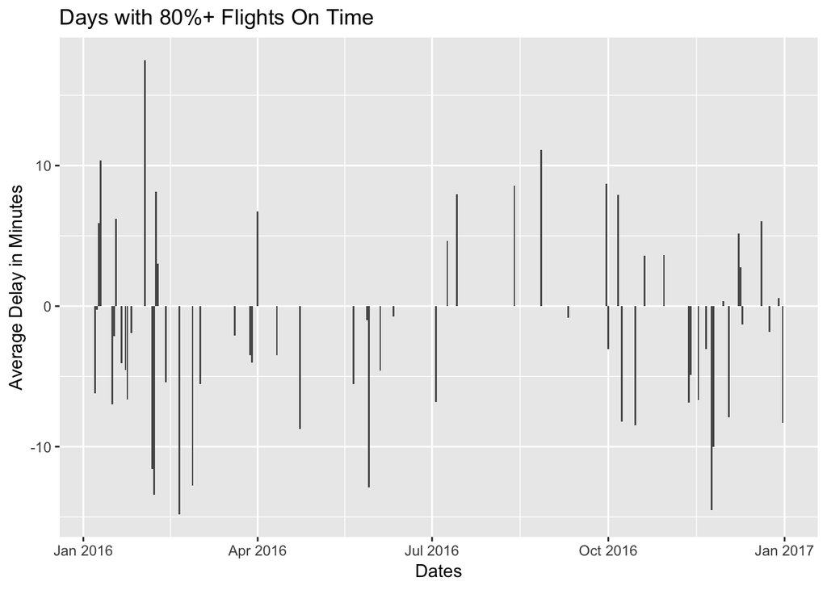

```r
# Filters down to days with at least 80% flights on time for better visualization.

ggplot(chi.flights.delay %>%
         filter(PROP_ON_TIME_80 == "TRUE", AVG_DELAY_BY_DAY <= 20)) +
  geom_bar(aes(x = FL_DATE,
               y = AVG_DELAY_BY_DAY),
           stat = "identity") +
  labs(x = "Dates",
       y = "Average Delay in Minutes",
       title = "Days with 80%+ Flights On Time")
```

```r
flights_to_chi <-
  chi.flights %>%
  filter(DEST == "ORD" | DEST == "MDW") %>%
  group_by(FL_DATE) %>%
  summarise(TOTAL_FL_BY_DAY = n()) %>%
  arrange(desc(TOTAL_FL_BY_DAY)
  )

print(flights_to_chi)
```

```
## # A tibble: 366 x 2
##    FL_DATE    TOTAL_FL_BY_DAY
##    <date>               <int>
##  1 2016-07-05            1033
##  2 2016-07-25            1030
##  3 2016-07-06            1028
##  4 2016-07-11            1028
##  5 2016-07-12            1028
##  6 2016-07-13            1028
##  7 2016-07-19            1027
##  8 2016-07-21            1027
##  9 2016-07-26            1027
## 10 2016-11-27            1027
## # ... with 356 more rows
```

```r
mean_no_flights = mean(flights_to_chi$TOTAL_FL_BY_DAY)
print(mean_no_flights)
```

```
## [1] 906.2596
```

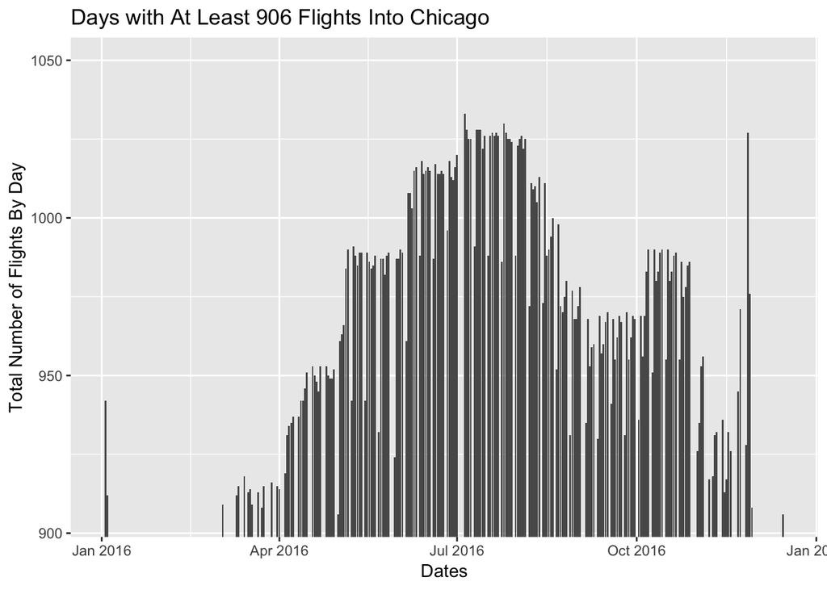

```r
# Filtering by number of flights/day exceeding the mean for visualization.

ggplot(flights_to_chi %>% filter(TOTAL_FL_BY_DAY >= 906)) +
  geom_bar(aes(x = FL_DATE,
               y = TOTAL_FL_BY_DAY),
           stat = "identity") +
  labs(x = "Dates",
       y = "Total Number of Flights By Day",
       title = "Days with At Least 906 Flights Into Chicago") +
  coord_cartesian(ylim = c(906, 1050))
```

Ans2.1.3.a We would recommend that the tourism board host the convention during early April, because not only are there above average number of flights flying into Chicago which allows for more flight options and flexibility, but the average delay is minimal.

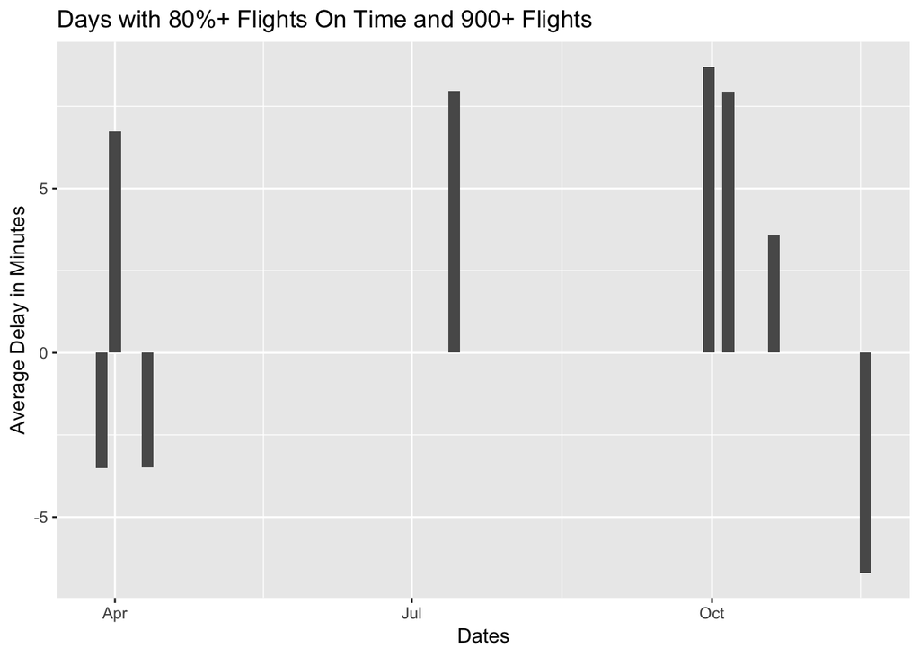

```r
ggplot(chi.flights.delay %>% filter(PROP_ON_TIME_80 == "TRUE", TOTAL_FL_BY_DAY >= 906)) +
  geom_bar(aes(x = FL_DATE,
               y = AVG_DELAY_BY_DAY),
           stat = "identity")+
  labs(x = "Dates",
       y = "Average Delay in Minutes",
       title = "Days with 80%+ Flights On Time and 900+ Flights")
```

Ans 2.1.3.b In this more sophisticated plot, we also included information on the day of the week. If we could only submit one plot, we would submit the more sophisticated one to provide more information in terms of not only which part of which month the convention should be held, but also which day of the week will allow the guests to have as many flight options and to arrive most on time.

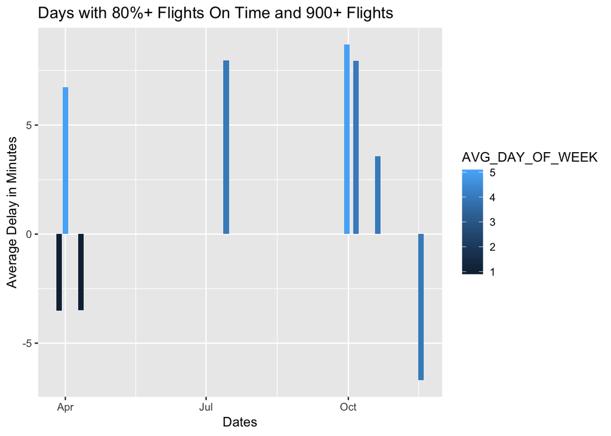

```r
ggplot(chi.flights.delay %>% filter(PROP_ON_TIME_80 == "TRUE",
      TOTAL_FL_BY_DAY >= 906)) +
  geom_bar(aes(
    x = FL_DATE,
    y = AVG_DELAY_BY_DAY,
    fill = AVG_DAY_OF_WEEK
  ),
  stat = "identity"
  ) +
  labs(
    x = "Dates",
    y = "Average Delay in Minutes",
    title = "Days with 80%+ Flights On Time and 900+ Flights"
  )
```

Ans 2.1.3.c

1. Weather Dataset
   - Because weather, specifically precitation levels in Chicago, tends to also impact flight arrival and delay times, we should also analyze weather patterns. Given average precitation levels for specific days of the year, we can determine whether there is a high likelihood of rain or other weather elements that will impact arrival of flights. Source: https://w2.weather.gov/climate/local_data.php?wfo=lot
2. Traffic Dataset
   - Another factor to take into account when planning a large scale event may be traffic. Analyzing data for the last few years to find dates/times in which traffic congestion is highest may be helpful. That being said, perhaps it may also be helpful to compile data for major events happening in the area including athletic/sports games, concerts, races, and conferences that may increase traffic. Source: https://data.cityofchicago.org/ Transportation/Chicago-Traffic-Tracker-Historical-Congestion-Esti/77hq-huss

## 2.3 Pick an airline

Ans 2.2.1 If the convention were to be during the period of April 5-April 15, we would recommend F9 (Frontier Airlines) for timeliness.

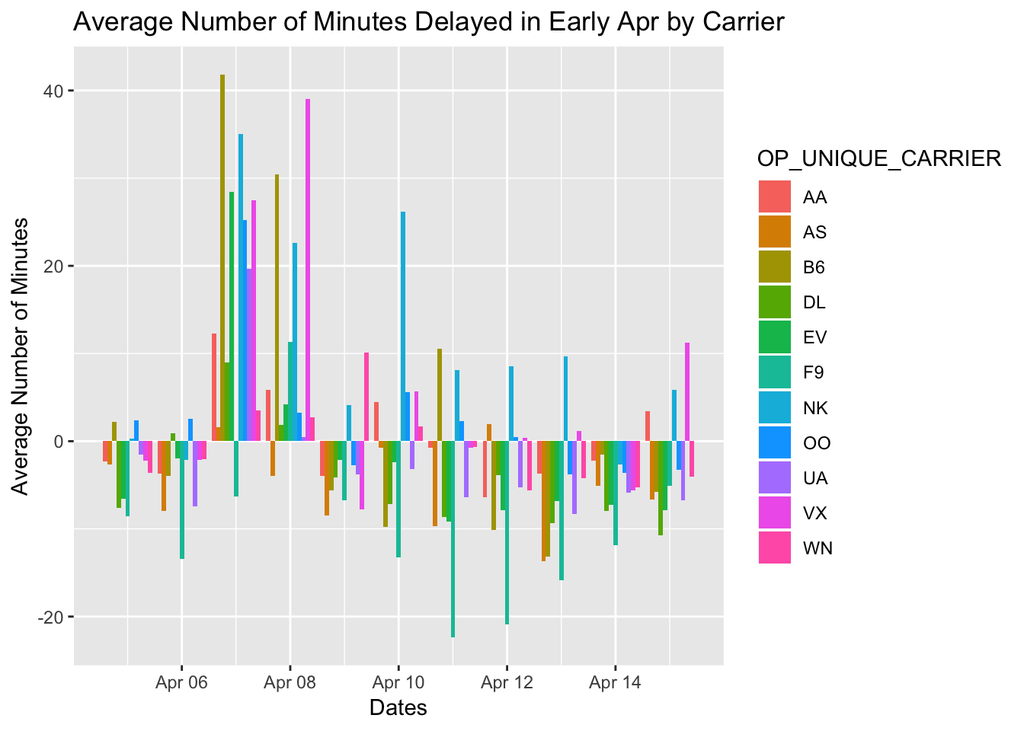

```r
avg_delay_carrier <-
  chi.flights %>%
  group_by(FL_DATE, OP_UNIQUE_CARRIER) %>%
  summarise(AVG_DELAY_CARRIER = mean(ARR_DELAY, na.rm = TRUE)) %>%
  filter(FL_DATE >= "2016-04-05" & FL_DATE <= "2016-04-15")

ggplot(avg_delay_carrier) +
  geom_bar(aes(
    x = FL_DATE,
    y = AVG_DELAY_CARRIER,
    fill = OP_UNIQUE_CARRIER
  ),
  stat = "identity",
  position = "dodge"
  ) +
  labs(
    x = "Dates",
    y = "Average Number of Minutes",
    title = "Average Number of Minutes Delayed in Early Apr by Carrier"
  )
```

## 2.4 Reconsider the date?

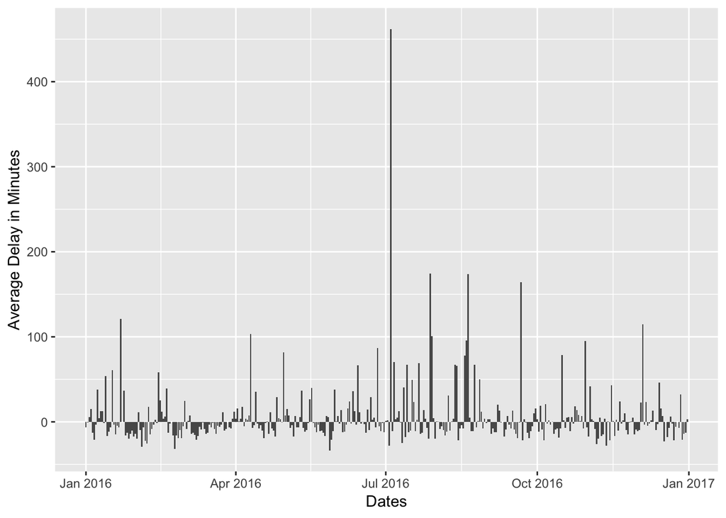

```r
flights_from_sc <-
  chi.flights %>%
  filter(ORIGIN == "GSP") %>%
  group_by(FL_DATE) %>%
  summarise(
    TOTAL_FL_BY_DAY = n(),
    AVG_DELAY_BY_DAY = mean(ARR_DELAY, na.rm = TRUE)
  )


ggplot(flights_from_sc) +
  geom_bar(aes(
    x = FL_DATE,
    y = AVG_DELAY_BY_DAY
  ),
  stat = "identity"
  ) +
  labs(
    x = "Dates",
    y = "Average Delay in Minutes"
  )
```